# Introduction to R: reading and examining data

Ville Karhunen

13th October 2021

Here, we go through some basic R data handling, plotting, and simple analyses. At the same time, this document is an example of an R Markdown report. Simply copy and paste each code block (in grey) to your Console window in RStudio. To copy a code block, you may use the shortcut in top left of each block.

## Read data

The example data is a fictious dataset of 56 individuals, from whom we have measured some basic variables. To read the data, type:

```r
d <- read.table("https://raw.githubusercontent.com/vkarhune/exampledata/main/example_dataset.txt", header = T, sep = "\t", stringsAsFactors = F)
```

Here we used a function called read.table(). You can go to the help page of any function by typing eg.

```r
?read.table
```

## Examine data

The data is now saved in an object called “d”. Some simple ways to examine the dataset:

```r
d # note that this can be done but is not practical if we are dealing with datasets with hundreds of rows or columns
```

```r
class(d)
```

```
## [1] "data.frame"
```

```r
str(d)
```

```
## 'data.frame':    56 obs. of  8 variables:
##  $ id         : int  152 126 107 125 187 190 132 184 124 157 ...
##  $ sex        : int  2 1 2 1 1 2 2 1 2 2 ...
##  $ education  : chr  "Higher education" "Higher education" "Higher education" "Higher education" ...
##  $ smoking    : chr  "Never" "Never" "Current" "Never" ...
##  $ height     : num  164 176 164 180 179 ...
##  $ weight     : num  59.7 65.5 35.9 96.2 85.4 76.7 56.6 76.2 58.4 78.3 ...
##  $ BPsystolic : int  120 132 118 129 118 139 113 119 117 121 ...
##  $ BPdiastolic: int  73 69 63 61 68 85 71 62 61 66 ...
```

```r
head(d)
```

```
##    id sex        education smoking height weight BPsystolic BPdiastolic
## 1 152   2 Higher education   Never  164.0   59.7        120          73
## 2 126   1 Higher education   Never  175.6   65.5        132          69
## 3 107   2 Higher education Current  163.7   35.9        118          63
## 4 125   1 Higher education   Never  179.7   96.2        129          61
## 5 187   1  Lower secondary  Former  179.3   85.4        118          68
## 6 190   2 Higher education  Former  177.4   76.7        139          85
```

```r
tail(d)
```

```
##     id sex        education smoking height weight BPsystolic BPdiastolic
## 51 161   2  Upper secondary   Never  156.5   58.4        112          71
## 52 189   2  Upper secondary  Former  174.2   67.5        110          63
## 53 148   1  Lower secondary   Never  167.9   92.3        150          87
## 54 193   2 Higher education   Never  160.0   63.8        108          66
## 55 153   2 Higher education Current  152.9   63.9        151          89
## 56 168   2 Higher education  Former  171.1   52.3        114          86
```

```r
names(d) # column names
```

```
## [1] "id"          "sex"         "education"   "smoking"     "height"
## [6] "weight"      "BPsystolic"  "BPdiastolic"
```

```r
# the columns can be referred in multiple ways
d[,3]
```

```
##  [1] "Higher education" "Higher education" "Higher education" "Higher education"
##  [5] "Lower secondary"  "Higher education" "Upper secondary"  "Higher education"
##  [9] "Higher education" "Higher education" "Upper secondary"  "Higher education"
## [13] "Higher education" "Higher education" "Higher education" "Higher education"
## [17] "Higher education" "Higher education" "Higher education" "Lower secondary"
## [21] "Higher education" "Higher education" "Higher education" "Upper secondary"
## [25] "Lower secondary"  "Higher education" "Higher education" "Higher education"
## [29] "Upper secondary"  "Upper secondary"  "Higher education" "Higher education"
## [33] "Higher education" "Higher education" "Lower secondary"  "Higher education"
## [37] "Higher education" "Higher education" "Higher education" "Higher education"
## [41] "Higher education" "Higher education" "Higher education" "Higher education"
## [45] "Upper secondary"  "Higher education" "Higher education" "Higher education"
## [49] "Higher education" "Higher education" "Upper secondary"  "Upper secondary"
## [53] "Lower secondary"  "Higher education" "Higher education" "Higher education"
```

```r
d[,"education"]
```

```
##  [1] "Higher education" "Higher education" "Higher education" "Higher education"
##  [5] "Lower secondary"  "Higher education" "Upper secondary"  "Higher education"
##  [9] "Higher education" "Higher education" "Upper secondary"  "Higher education"
## [13] "Higher education" "Higher education" "Higher education" "Higher education"
## [17] "Higher education" "Higher education" "Higher education" "Lower secondary"
## [21] "Higher education" "Higher education" "Higher education" "Upper secondary"
## [25] "Lower secondary"  "Higher education" "Higher education" "Higher education"
## [29] "Upper secondary"  "Upper secondary"  "Higher education" "Higher education"
## [33] "Higher education" "Higher education" "Lower secondary"  "Higher education"
## [37] "Higher education" "Higher education" "Higher education" "Higher education"
## [41] "Higher education" "Higher education" "Higher education" "Higher education"
## [45] "Upper secondary"  "Higher education" "Higher education" "Higher education"
## [49] "Higher education" "Higher education" "Upper secondary"  "Upper secondary"
## [53] "Lower secondary"  "Higher education" "Higher education" "Higher education"
```

```r
d$education
```

```
##  [1] "Higher education" "Higher education" "Higher education" "Higher education"
##  [5] "Lower secondary"  "Higher education" "Upper secondary"  "Higher education"
##  [9] "Higher education" "Higher education" "Upper secondary"  "Higher education"
## [13] "Higher education" "Higher education" "Higher education" "Higher education"
## [17] "Higher education" "Higher education" "Higher education" "Lower secondary"
## [21] "Higher education" "Higher education" "Higher education" "Upper secondary"
## [25] "Lower secondary"  "Higher education" "Higher education" "Higher education"
## [29] "Upper secondary"  "Upper secondary"  "Higher education" "Higher education"
## [33] "Higher education" "Higher education" "Lower secondary"  "Higher education"
## [37] "Higher education" "Higher education" "Higher education" "Higher education"
## [41] "Higher education" "Higher education" "Higher education" "Higher education"
## [45] "Upper secondary"  "Higher education" "Higher education" "Higher education"
## [49] "Higher education" "Higher education" "Upper secondary"  "Upper secondary"
## [53] "Lower secondary"  "Higher education" "Higher education" "Higher education"
```

```r
d[1:10,2]
```

```
##  [1] 2 1 2 1 1 2 2 1 2 2
```

```r
d[1:10,"sex"] # the same as above
```

```
##  [1] 2 1 2 1 1 2 2 1 2 2
```

```r
d[c(1,3,5),c("id", "smoking")]
```

```
##    id smoking
## 1 152   Never
## 3 107 Current
## 5 187  Former
```

```r
d[d$smoking %in% "Current",]
```

```
##     id sex        education smoking height weight BPsystolic BPdiastolic
## 3  107   2 Higher education Current  163.7   35.9        118          63
## 12 201   2 Higher education Current  160.7   63.1        123          60
## 14 114   2 Higher education Current  171.4   48.7        108          86
## 26 160   1 Higher education Current  179.4   77.0        148          92
## 35 203   2  Lower secondary Current  173.4   78.8        125          72
## 39 166   2 Higher education Current  157.1   82.7        116          78
## 40 104   2 Higher education Current  171.4   77.8        146          94
## 42 209   2 Higher education Current  165.1   69.1        113          52
## 47 142   2 Higher education Current  168.7   85.4        142          86
## 55 153   2 Higher education Current  152.9   63.9        151          89
```

```r
View(d)
```

## Data handling

Let’s create a new variable of body mass index (BMI), given as weight (in kg) divided by height (in meters) squared:

```r
d$bmi <- d$weight/((d$height/100)^2)

head(d)
```

```
##    id sex        education smoking height weight BPsystolic BPdiastolic      bmi
## 1 152   2 Higher education   Never  164.0   59.7        120          73 22.19661
## 2 126   1 Higher education   Never  175.6   65.5        132          69 21.24185
## 3 107   2 Higher education Current  163.7   35.9        118          63 13.39668
## 4 125   1 Higher education   Never  179.7   96.2        129          61 29.79058
## 5 187   1  Lower secondary  Former  179.3   85.4        118          68 26.56423
## 6 190   2 Higher education  Former  177.4   76.7        139          85 24.37183
```

## Desctiptives

Some simple descriptive statistics:

```r
table(d$smoking)
```

```
##
## Current  Former   Never
##      10      17      29
```

```r
prop.table(table(d$smoking))
```

```
##
##   Current    Former     Never
## 0.1785714 0.3035714 0.5178571
```

```r
table(d$education, d$smoking)
```

```
##
##                    Current Former Never
##   Higher education       9     11    23
##   Lower secondary        1      2     2
##   Upper secondary        0      4     4
```

```r
prop.table(table(d$education, d$smoking), margin = 1)
```

```
##
##                      Current    Former     Never
##   Higher education 0.2093023 0.2558140 0.5348837
##   Lower secondary  0.2000000 0.4000000 0.4000000
##   Upper secondary  0.0000000 0.5000000 0.5000000
```

And for continuous variables:

```r
mean(d$bmi)
```

```
## [1] 24.8708
```

```r
sd(d$bmi)
```

```
## [1] 4.105323
```

```r
summary(d$BPsystolic) # note that the variable names are case-sensitive
```

```
##    Min. 1st Qu.  Median    Mean 3rd Qu.    Max.
##   101.0   114.0   122.0   125.6   134.2   158.0
```

Grouping by categories:

```r
tapply(d$height, d$sex, summary)
```

```
## $`1`
##    Min. 1st Qu.  Median    Mean 3rd Qu.    Max.
##   167.9   174.8   177.1   177.5   179.4   189.8
##
## $`2`
##    Min. 1st Qu.  Median    Mean 3rd Qu.    Max.
##   152.9   163.4   165.8   166.1   170.8   177.4
```

## Plots

Below are some demonstrations to create simple graphs using base R. Please note that there are further packages for fancier graphics (e.g. *ggplot2* package, which will be used in the Stats II module).

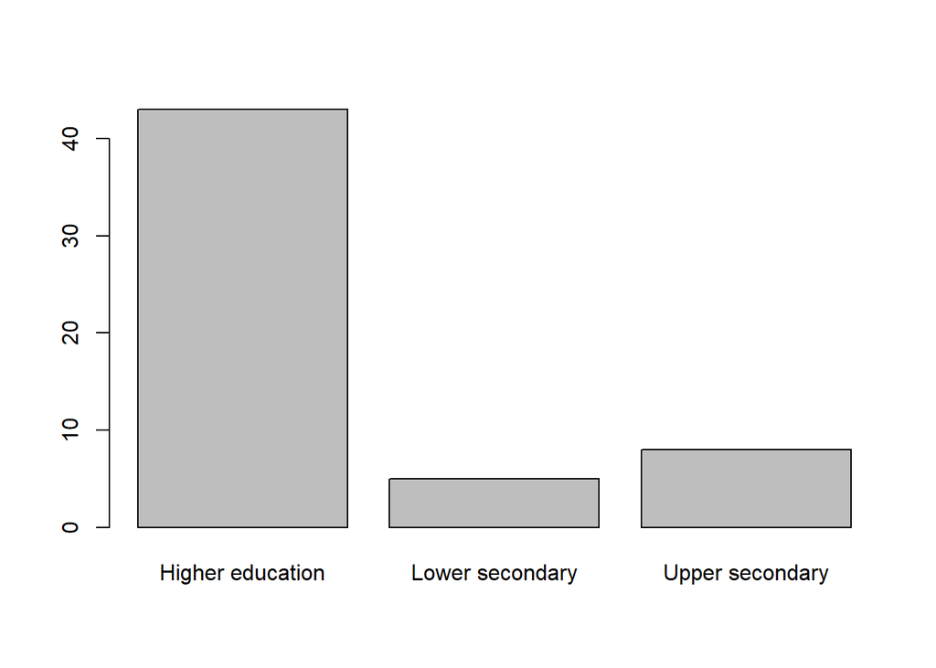

```r
barplot(table(d$education))
```

Can be adjusted further:

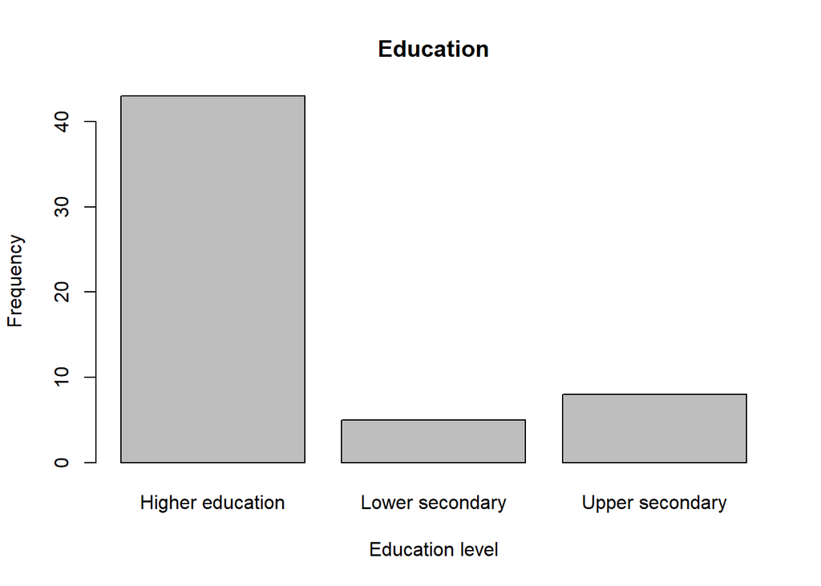

```r
barplot(table(d$education), main = "Education", xlab = "Education level",
        ylab = "Frequency")
```

Continuous variables:

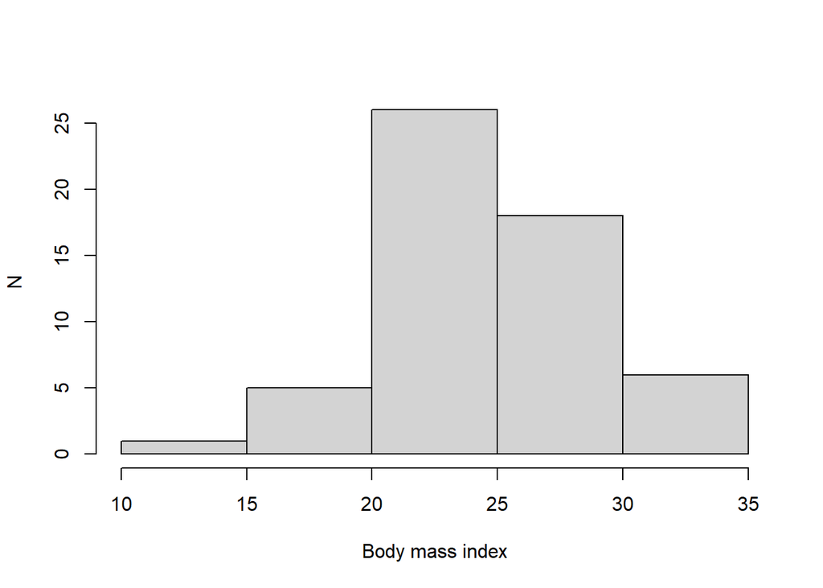

```r
hist(d$bmi, main = "", xlab = "Body mass index", ylab = "N")
```

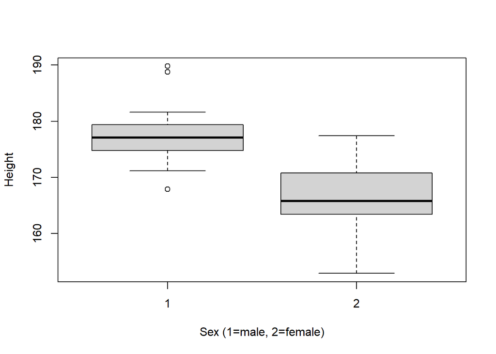

```r
boxplot(d$height ~ d$sex, xlab = "Sex (1=male, 2=female)",
        ylab = "Height")
```

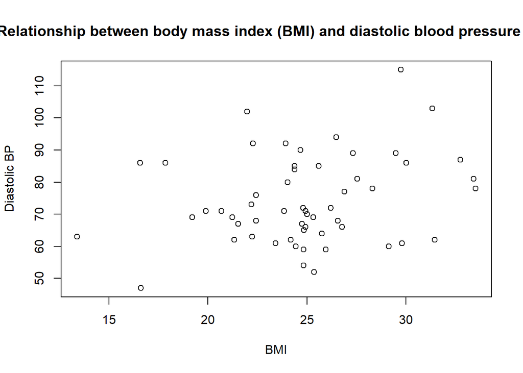

```r
plot(d$bmi, d$BPdiastolic, main = "Relationship between body mass index (BMI) and diastolic blood pressure (BP)", xlab = "BMI", ylab = "Diastolic BP")
```

What is the observation with the lowest BMI?

```r
d[d$bmi < 15,]
```

```
##    id sex        education smoking height weight BPsystolic BPdiastolic      bmi
## 3 107   2 Higher education Current  163.7   35.9        118          63 13.39668
```

After checking with the hosting data team, we receive a confirmation that the correct weight should be 53.9. We can edit the data as follows:

```r
d[d$id == 107, "weight"] # gives the original
```

```
## [1] 35.9
```

```r
d[d$id == 107,"weight"] <- 53.9 # assign

d[d$id == 107,"weight"] # check the new value
```

```
## [1] 53.9
```

Remember to create the BMI variable again (or, in practice, this edit would be added in the beginning of the script, right after reading in the data):

```r
d$bmi <- d$weight/((d$height/100)^2)

# and check again:
d[d$id == 107,]
```

```
##    id sex        education smoking height weight BPsystolic BPdiastolic      bmi
## 3 107   2 Higher education Current  163.7   53.9        118          63 20.11367
```

And a new plot:

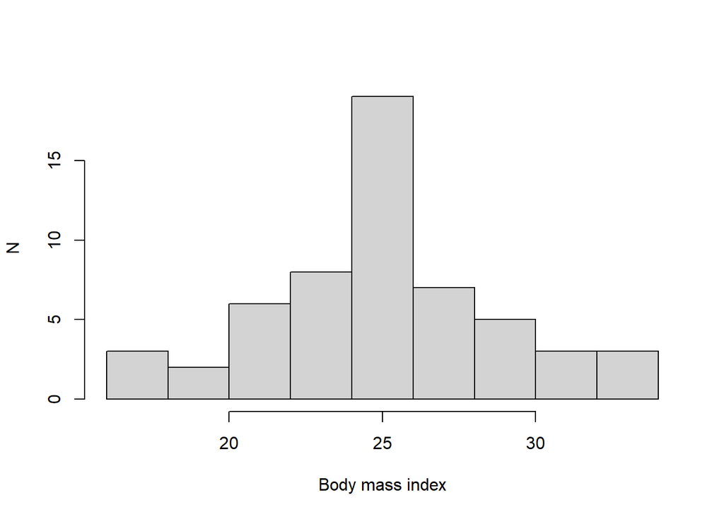

```r
hist(d$bmi, main = "", xlab = "Body mass index", ylab = "N")
```

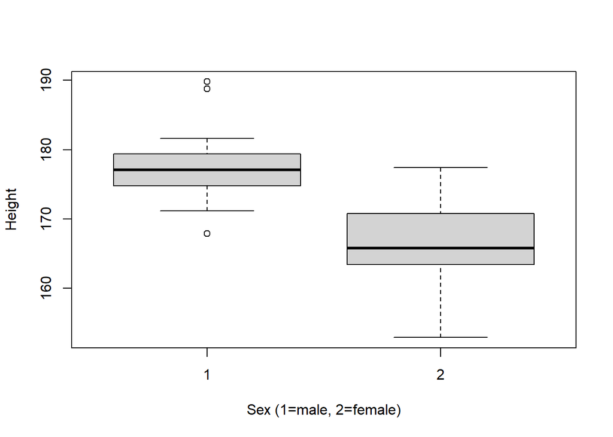

```r
boxplot(d$height ~ d$sex, xlab = "Sex (1=male, 2=female)",
        ylab = "Height")
```

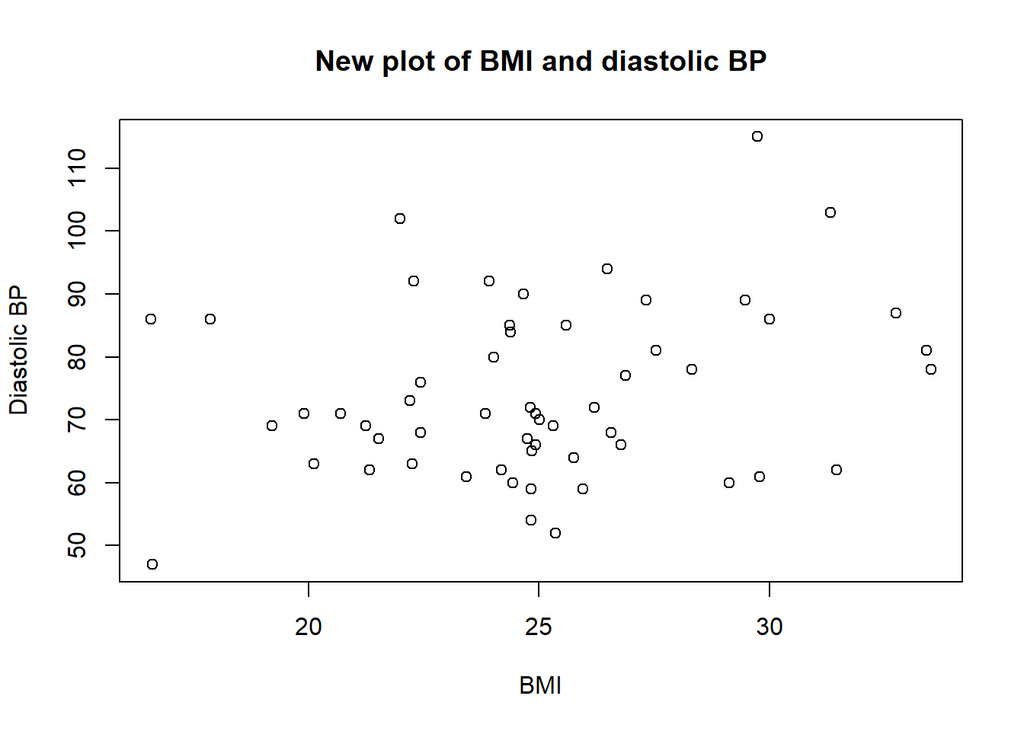

```r
plot(d$bmi, d$BPdiastolic, main = "New plot of BMI and diastolic BP", xlab = "BMI", ylab = "Diastolic BP")
```

## Statistical analysis

Simple examples of statistical analyses – a chi-squared test to examine the relationship between sex and smoking status:

```r
chisq.test(d$sex, d$smoking)
```

```
##
##  Pearson's Chi-squared test
##
## data:  d$sex and d$smoking
## X-squared = 6.2046, df = 2, p-value = 0.04495
```

Typically, we save the test results to an object, and access the values from the object:

```r
test1 <- chisq.test(d$sex, d$smoking)
test1
```

```
##
##  Pearson's Chi-squared test
##
## data:  d$sex and d$smoking
## X-squared = 6.2046, df = 2, p-value = 0.04495
```

```r
str(test1)
```

```
## List of 9
##  $ statistic: Named num 6.2
##   ..- attr(*, "names")= chr "X-squared"
##  $ parameter: Named int 2
##   ..- attr(*, "names")= chr "df"
##  $ p.value  : num 0.0449
##  $ method   : chr "Pearson's Chi-squared test"
##  $ data.name: chr "d$sex and d$smoking"
##  $ observed : 'table' int [1:2, 1:3] 1 9 5 12 15 14
##   ..- attr(*, "dimnames")=List of 2
##   .. ..$ d$sex    : chr [1:2] "1" "2"
##   .. ..$ d$smoking: chr [1:3] "Current" "Former" "Never"
##  $ expected : num [1:2, 1:3] 3.75 6.25 6.38 10.62 10.88 ...
##   ..- attr(*, "dimnames")=List of 2
##   .. ..$ d$sex    : chr [1:2] "1" "2"
##   .. ..$ d$smoking: chr [1:3] "Current" "Former" "Never"
##  $ residuals: 'table' num [1:2, 1:3] -1.42 1.1 -0.545 0.422 1.251 ...
##   ..- attr(*, "dimnames")=List of 2
##   .. ..$ d$sex    : chr [1:2] "1" "2"
##   .. ..$ d$smoking: chr [1:3] "Current" "Former" "Never"
##  $ stdres   : 'table' num [1:2, 1:3] -1.982 1.982 -0.825 0.825 2.279 ...
##   ..- attr(*, "dimnames")=List of 2
##   .. ..$ d$sex    : chr [1:2] "1" "2"
##   .. ..$ d$smoking: chr [1:3] "Current" "Former" "Never"
##  - attr(*, "class")= chr "htest"
```

```r
test1$p.value
```

```
## [1] 0.04494515
```

T-test to examine the whether mean BMI is different between males and females:

```r
test2 <- t.test(d$bmi ~ d$sex)

test2
```

```
##
##  Welch Two Sample t-test
##
## data:  d$bmi by d$sex
## t = 1.7493, df = 43.987, p-value = 0.08721
## alternative hypothesis: true difference in means is not equal to 0
## 95 percent confidence interval:
##  -0.2745389  3.8842995
## sample estimates:
## mean in group 1 mean in group 2
##        26.11879        24.31391
```

```r
str(test2)
```

```
## List of 10
##  $ statistic  : Named num 1.75
##   ..- attr(*, "names")= chr "t"
##  $ parameter  : Named num 44
##   ..- attr(*, "names")= chr "df"
##  $ p.value    : num 0.0872
##  $ conf.int   : num [1:2] -0.275 3.884
##   ..- attr(*, "conf.level")= num 0.95
##  $ estimate   : Named num [1:2] 26.1 24.3
##   ..- attr(*, "names")= chr [1:2] "mean in group 1" "mean in group 2"
##  $ null.value : Named num 0
##   ..- attr(*, "names")= chr "difference in means"
##  $ stderr     : num 1.03
##  $ alternative: chr "two.sided"
##  $ method     : chr "Welch Two Sample t-test"
##  $ data.name  : chr "d$bmi by d$sex"
##  - attr(*, "class")= chr "htest"
```

```r
test2$conf.int
```

```
## [1] -0.2745389  3.8842995
## attr(,"conf.level")
## [1] 0.95
```